# project1

**PROJECT: An Introduction of TMDB dataset INTRODUCTION:I choose the TMDB-Movies dataset for the this investigate a dataset project.In this dataset some of the important data values provided for the analysis, by analysing this dataset we can conclude which genres of movie is more popular ,which movie earned more profit over the years, what are the criteria's for a movie to be successful.**

**Research questions**:

**1) What is the proift of the movies from the dataset over the years?**

**2) Which is the worst year amongst all the years to release movie in theatre or make profit?**

**3) Year of Release Vs the Profitability of the movies?**

**4) What is the average run time of all movies from dataset?**

**5) What are the movies genres present in the dataset? and which are the most popular genre year to year to make movies?**

**6) Which movie has minimum profit?**

**7)Which movie has maximum profit?**

**8) What us relaton between budget and revenue?**

**9) What is relation between popularity and runtime?**

```python
#loading the packages required for the analysis
import pandas as pd
import numpy as np
import matplotlib.pyplot as plt
%matplotlib inline
```

**Read the csv file to understand the data**

```python
df_tmdb = pd.read_csv('tmdb-movies.csv')
df_tmdb
```

|  | id | imdb_id | popularity | budget | revenue | original_title | cast | homepage | director | tagline | ... | overview | runtime | genres | production_companies | release_date | vote_count | vote_average | release_year | budget_adj | revenue_adj |
| --- | --- | --- | --- | --- | --- | --- | --- | --- | --- | --- | --- | --- | --- | --- | --- | --- | --- | --- | --- | --- | --- |
| 0 | 135397 | tt0369610 | 32.985763 | 150000000 | 1513528810 | Jurassic World | Chris Pratt\|Bryce Dallas Howard\|Irrfan Khan\|Vi... | http://www.jurassicworld.com/ | Colin Trevorrow | The park is open. | ... | Twenty-two years after the events of Jurassic ... | 124 | Action\|Adventure\|Science Fiction\|Thriller | Universal Studios\|Amblin Entertainment\|Legenda... | 6/9/15 | 5562 | 6.5 | 2015 | 1.379999e+08 | 1.392446e+09 |
| 1 | 76341 | tt1392190 | 28.419936 | 150000000 | 378436354 | Mad Max: Fury Road | Tom Hardy\|Charlize Theron\|Hugh Keays-Byrne\|Nic... | http://www.madmaxmovie.com/ | George Miller | What a Lovely Day. | ... | An apocalyptic story set in the furthest reach... | 120 | Action\|Adventure\|Science Fiction\|Thriller | Village Roadshow Pictures\|Kennedy Miller Produ... | 5/13/15 | 6185 | 7.1 | 2015 | 1.379999e+08 | 3.481613e+08 |
| 2 | 262500 | tt2908446 | 13.112507 | 110000000 | 295238201 | Insurgent | Shailene Woodley\|Theo James\|Kate Winslet\|Ansel... | http://www.thedivergentseries.movie/#insurgent | Robert Schwentke | One Choice Can Destroy You | ... | Beatrice Prior must confront her inner demons ... | 119 | Adventure\|Science Fiction\|Thriller | Summit Entertainment\|Mandeville Films\|Red Wago... | 3/18/15 | 2480 | 6.3 | 2015 | 1.012000e+08 | 2.716190e+08 |
| 3 | 140607 | tt2488496 | 11.173104 | 200000000 | 2068178225 | Star Wars: The Force Awakens | Harrison Ford\|Mark Hamill\|Carrie Fisher\|Adam D... | http://www.starwars.com/films/star-wars-episod... | J.J. Abrams | Every generation has a story. | ... | Thirty years after defeating the Galactic Empi... | 136 | Action\|Adventure\|Science Fiction\|Fantasy | Lucasfilm\|Truenorth Productions\|Bad Robot | 12/15/15 | 5292 | 7.5 | 2015 | 1.839999e+08 | 1.902723e+09 |
| 4 | 168259 | tt2820852 | 9.335014 | 190000000 | 1506249360 | Furious 7 | Vin Diesel\|Paul Walker\|Jason Statham\|Michelle ... | http://www.furious7.com/ | James Wan | Vengeance Hits Home | ... | Deckard Shaw seeks revenge against Dominic Tor... | 137 | Action\|Crime\|Thriller | Universal Pictures\|Original Film\|Media Rights ... | 4/1/15 | 2947 | 7.3 | 2015 | 1.747999e+08 | 1.385749e+09 |
| ... | ... | ... | ... | ... | ... | ... | ... | ... | ... | ... | ... | ... | ... | ... | ... | ... | ... | ... | ... | ... | ... |
| 10861 | 21 | tt0060371 | 0.080598 | 0 | 0 | The Endless Summer | Michael Hynson\|Robert August\|Lord 'Tally Ho' B... | NaN | Bruce Brown | NaN | ... | The Endless Summer, by Bruce Brown, is one of ... | 95 | Documentary | Bruce Brown Films | 6/15/66 | 11 | 7.4 | 1966 | 0.000000e+00 | 0.000000e+00 |
| 10862 | 20379 | tt0060472 | 0.065543 | 0 | 0 | Grand Prix | James Garner\|Eva Marie Saint\|Yves Montand\|Tosh... | NaN | John Frankenheimer | Cinerama sweeps YOU into a drama of speed and ... | ... | Grand Prix driver Pete Aron is fired by his te... | 176 | Action\|Adventure\|Drama | Cherokee Productions\|Joel Productions\|Douglas ... | 12/21/66 | 20 | 5.7 | 1966 | 0.000000e+00 | 0.000000e+00 |
| 10863 | 39768 | tt0060161 | 0.065141 | 0 | 0 | Beregis Avtomobilya | Innokentiy Smoktunovskiy\|Oleg Efremov\|Georgi Z... | NaN | Eldar Ryazanov | NaN | ... | An insurance agent who moonlights as a carthie... | 94 | Mystery\|Comedy | Mosfilm | 1/1/66 | 11 | 6.5 | 1966 | 0.000000e+00 | 0.000000e+00 |
| 10864 | 21449 | tt0061177 | 0.064317 | 0 | 0 | What's Up, Tiger Lily? | Tatsuya Mihashi\|Akiko Wakabayashi\|Mie Hama\|Joh... | NaN | Woody Allen | WOODY ALLEN STRIKES BACK! | ... | In comic Woody Allen's film debut, he took the... | 80 | Action\|Comedy | Benedict Pictures Corp. | 11/2/66 | 22 | 5.4 | 1966 | 0.000000e+00 | 0.000000e+00 |
| 10865 | 22293 | tt0060666 | 0.035919 | 19000 | 0 | Manos: The Hands of Fate | Harold P. Warren\|Tom Neyman\|John Reynolds\|Dian... | NaN | Harold P. Warren | It's Shocking! It's Beyond Your Imagination! | ... | A family gets lost on the road and stumbles up... | 74 | Horror | Norm-Iris | 11/15/66 | 15 | 1.5 | 1966 | 1.276423e+05 | 0.000000e+00 |

10866 rows × 21 columns

**-DATA WRANGLING**

**Data cleaning process**:

**1)Check for the null values present in the dataset**

**2)Check for duplicate value present in the dataset**

**3)Removing all the unwanted columns which are not useful for cleaning from dataset**

**4)Change the datetime format of dataset**

**5)Replace all the null or zero values**

**6)Which movie has minimum profit?**

**7)Which movie has maximum profit?**

```python
#To check null values and column from data set
df_tmdb.info()
```

```
<class 'pandas.core.frame.DataFrame'>
RangeIndex: 10866 entries, 0 to 10865
Data columns (total 21 columns):
 #   Column                Non-Null Count  Dtype
---  ------                --------------  -----
 0   id                    10866 non-null  int64
 1   imdb_id               10856 non-null  object
 2   popularity            10866 non-null  float64
 3   budget                10866 non-null  int64
 4   revenue               10866 non-null  int64
 5   original_title        10866 non-null  object
 6   cast                  10790 non-null  object
 7   homepage              2936 non-null   object
 8   director              10822 non-null  object
 9   tagline               8042 non-null   object
 10  keywords              9373 non-null   object
 11  overview              10862 non-null  object
 12  runtime               10866 non-null  int64
 13  genres                10843 non-null  object
 14  production_companies  9836 non-null   object
 15  release_date          10866 non-null  object
 16  vote_count            10866 non-null  int64
 17  vote_average          10866 non-null  float64
 18  release_year          10866 non-null  int64
 19  budget_adj            10866 non-null  float64
 20  revenue_adj           10866 non-null  float64
dtypes: float64(4), int64(6), object(11)
memory usage: 1.7+ MB
```

```python
#To fill for all missing values from data set
df_tmdb.fillna(df_tmdb.mean(),inplace = True)
df_tmdb.info()
```

```
<class 'pandas.core.frame.DataFrame'>
RangeIndex: 10866 entries, 0 to 10865
Data columns (total 21 columns):
 #   Column                Non-Null Count  Dtype
---  ------                --------------  -----
 0   id                    10866 non-null  int64
 1   imdb_id               10856 non-null  object
 2   popularity            10866 non-null  float64
 3   budget                10866 non-null  int64
 4   revenue               10866 non-null  int64
 5   original_title        10866 non-null  object
 6   cast                  10790 non-null  object
 7   homepage              2936 non-null   object
 8   director              10822 non-null  object
 9   tagline               8042 non-null   object
 10  keywords              9373 non-null   object
 11  overview              10862 non-null  object
 12  runtime               10866 non-null  int64
 13  genres                10843 non-null  object
 14  production_companies  9836 non-null   object
 15  release_date          10866 non-null  object
 16  vote_count            10866 non-null  int64
 17  vote_average          10866 non-null  float64
 18  release_year          10866 non-null  int64
 19  budget_adj            10866 non-null  float64
 20  revenue_adj           10866 non-null  float64
dtypes: float64(4), int64(6), object(11)
memory usage: 1.7+ MB
```

```python
# check for duplicates in the data
sum(df_tmdb.duplicated())
```

```
1
```

```python
# drop duplicates
df_tmdb.drop_duplicates(inplace=True)
```

```python
# confirm correction by rechecking for duplicates in the data
sum(df_tmdb.duplicated())
```

```
0
```

```python
#Removing unwanted columns from the dataset
df_tmdb.drop(['id','imdb_id','homepage','keywords','overview','production_companies','tagline','budget_adj','revenue_adj','vote_count','vote_average'], axis=1, inplace=True)
df_tmdb
```

|  | popularity | budget | revenue | original_title | cast | director | runtime | genres | release_date | release_year |
| --- | --- | --- | --- | --- | --- | --- | --- | --- | --- | --- |
| 0 | 32.985763 | 150000000 | 1513528810 | Jurassic World | Chris Pratt\|Bryce Dallas Howard\|Irrfan Khan\|Vi... | Colin Trevorrow | 124 | Action\|Adventure\|Science Fiction\|Thriller | 6/9/15 | 2015 |
| 1 | 28.419936 | 150000000 | 378436354 | Mad Max: Fury Road | Tom Hardy\|Charlize Theron\|Hugh Keays-Byrne\|Nic... | George Miller | 120 | Action\|Adventure\|Science Fiction\|Thriller | 5/13/15 | 2015 |
| 2 | 13.112507 | 110000000 | 295238201 | Insurgent | Shailene Woodley\|Theo James\|Kate Winslet\|Ansel... | Robert Schwentke | 119 | Adventure\|Science Fiction\|Thriller | 3/18/15 | 2015 |
| 3 | 11.173104 | 200000000 | 2068178225 | Star Wars: The Force Awakens | Harrison Ford\|Mark Hamill\|Carrie Fisher\|Adam D... | J.J. Abrams | 136 | Action\|Adventure\|Science Fiction\|Fantasy | 12/15/15 | 2015 |
| 4 | 9.335014 | 190000000 | 1506249360 | Furious 7 | Vin Diesel\|Paul Walker\|Jason Statham\|Michelle ... | James Wan | 137 | Action\|Crime\|Thriller | 4/1/15 | 2015 |
| ... | ... | ... | ... | ... | ... | ... | ... | ... | ... | ... |
| 10861 | 0.080598 | 0 | 0 | The Endless Summer | Michael Hynson\|Robert August\|Lord 'Tally Ho' B... | Bruce Brown | 95 | Documentary | 6/15/66 | 1966 |
| 10862 | 0.065543 | 0 | 0 | Grand Prix | James Garner\|Eva Marie Saint\|Yves Montand\|Tosh... | John Frankenheimer | 176 | Action\|Adventure\|Drama | 12/21/66 | 1966 |
| 10863 | 0.065141 | 0 | 0 | Beregis Avtomobilya | Innokentiy Smoktunovskiy\|Oleg Efremov\|Georgi Z... | Eldar Ryazanov | 94 | Mystery\|Comedy | 1/1/66 | 1966 |
| 10864 | 0.064317 | 0 | 0 | What's Up, Tiger Lily? | Tatsuya Mihashi\|Akiko Wakabayashi\|Mie Hama\|Joh... | Woody Allen | 80 | Action\|Comedy | 11/2/66 | 1966 |
| 10865 | 0.035919 | 19000 | 0 | Manos: The Hands of Fate | Harold P. Warren\|Tom Neyman\|John Reynolds\|Dian... | Harold P. Warren | 74 | Horror | 11/15/66 | 1966 |

10865 rows × 10 columns

```python
#replace zeros with null values in the budget and revenue column
df_tmdb['budget']= df_tmdb['budget'].replace(0,np.NaN)
df_tmdb['revenue']= df_tmdb['revenue'].replace(0,np.NaN)
df_tmdb['cast']= df_tmdb['cast'].replace(0,np.NaN)
df_tmdb['runtime']= df_tmdb['runtime'].replace(0,np.NaN)
df_tmdb.info()
```

```
<class 'pandas.core.frame.DataFrame'>
Int64Index: 10865 entries, 0 to 10865
Data columns (total 10 columns):
 #   Column          Non-Null Count  Dtype
---  ------          --------------  -----
 0   popularity      10865 non-null  float64
 1   budget          5169 non-null   float64
 2   revenue         4849 non-null   float64
 3   original_title  10865 non-null  object
 4   cast            10789 non-null  object
 5   director        10821 non-null  object
 6   runtime         10834 non-null  float64
 7   genres          10842 non-null  object
 8   release_date    10865 non-null  object
 9   release_year    10865 non-null  int64
dtypes: float64(4), int64(1), object(5)
memory usage: 933.7+ KB
```

```python
#changing the release date column into standard date format
df_tmdb.release_date = pd.to_datetime(df_tmdb['release_date'])
df_tmdb.head()
```

|  | popularity | budget | revenue | original_title | cast | director | runtime | genres | release_date | release_year |
| --- | --- | --- | --- | --- | --- | --- | --- | --- | --- | --- |
| 0 | 32.985763 | 150000000.0 | 1.513529e+09 | Jurassic World | Chris Pratt\|Bryce Dallas Howard\|Irrfan Khan\|Vi... | Colin Trevorrow | 124.0 | Action\|Adventure\|Science Fiction\|Thriller | 2015-06-09 | 2015 |
| 1 | 28.419936 | 150000000.0 | 3.784364e+08 | Mad Max: Fury Road | Tom Hardy\|Charlize Theron\|Hugh Keays-Byrne\|Nic... | George Miller | 120.0 | Action\|Adventure\|Science Fiction\|Thriller | 2015-05-13 | 2015 |
| 2 | 13.112507 | 110000000.0 | 2.952382e+08 | Insurgent | Shailene Woodley\|Theo James\|Kate Winslet\|Ansel... | Robert Schwentke | 119.0 | Adventure\|Science Fiction\|Thriller | 2015-03-18 | 2015 |
| 3 | 11.173104 | 200000000.0 | 2.068178e+09 | Star Wars: The Force Awakens | Harrison Ford\|Mark Hamill\|Carrie Fisher\|Adam D... | J.J. Abrams | 136.0 | Action\|Adventure\|Science Fiction\|Fantasy | 2015-12-15 | 2015 |
| 4 | 9.335014 | 190000000.0 | 1.506249e+09 | Furious 7 | Vin Diesel\|Paul Walker\|Jason Statham\|Michelle ... | James Wan | 137.0 | Action\|Crime\|Thriller | 2015-04-01 | 2015 |

```python
#checking the data type of dataset
df_tmdb.dtypes
```

```
popularity               float64
budget                   float64
revenue                  float64
original_title            object
cast                      object
director                  object
runtime                  float64
genres                    object
release_date      datetime64[ns]
release_year               int64
dtype: object
```

**As the data type of dataset is correct, so there is no need to change any data type from dataset**

**Research Question 1) What is the proift of the movies from the dataset over the years?**

```python
#Calculating profit of each movies from dataset
df_tmdb.insert(3,'profit',df_tmdb['revenue']-df_tmdb['budget'])
df_tmdb.head()
```

|  | popularity | budget | revenue | profit | original_title | cast | director | runtime | genres | release_date | release_year |
| --- | --- | --- | --- | --- | --- | --- | --- | --- | --- | --- | --- |
| 0 | 32.985763 | 150000000.0 | 1.513529e+09 | 1.363529e+09 | Jurassic World | Chris Pratt\|Bryce Dallas Howard\|Irrfan Khan\|Vi... | Colin Trevorrow | 124.0 | Action\|Adventure\|Science Fiction\|Thriller | 2015-06-09 | 2015 |
| 1 | 28.419936 | 150000000.0 | 3.784364e+08 | 2.284364e+08 | Mad Max: Fury Road | Tom Hardy\|Charlize Theron\|Hugh Keays-Byrne\|Nic... | George Miller | 120.0 | Action\|Adventure\|Science Fiction\|Thriller | 2015-05-13 | 2015 |
| 2 | 13.112507 | 110000000.0 | 2.952382e+08 | 1.852382e+08 | Insurgent | Shailene Woodley\|Theo James\|Kate Winslet\|Ansel... | Robert Schwentke | 119.0 | Adventure\|Science Fiction\|Thriller | 2015-03-18 | 2015 |
| 3 | 11.173104 | 200000000.0 | 2.068178e+09 | 1.868178e+09 | Star Wars: The Force Awakens | Harrison Ford\|Mark Hamill\|Carrie Fisher\|Adam D... | J.J. Abrams | 136.0 | Action\|Adventure\|Science Fiction\|Fantasy | 2015-12-15 | 2015 |
| 4 | 9.335014 | 190000000.0 | 1.506249e+09 | 1.316249e+09 | Furious 7 | Vin Diesel\|Paul Walker\|Jason Statham\|Michelle ... | James Wan | 137.0 | Action\|Crime\|Thriller | 2015-04-01 | 2015 |

```python
#Worst year to release movie in theatre
df_tmdb[df_tmdb['release_year'] == df_tmdb['release_year'].min()]
```

|  | popularity | budget | revenue | profit | original_title | cast | director | runtime | genres | release_date | release_year |
| --- | --- | --- | --- | --- | --- | --- | --- | --- | --- | --- | --- |
| 10141 | 2.610362 | 806948.0 | 32000000.0 | 31193052.0 | Psycho | Anthony Perkins\|Vera Miles\|John Gavin\|Janet Le... | Alfred Hitchcock | 109.0 | Drama\|Horror\|Thriller | 2060-08-14 | 1960 |
| 10142 | 1.872132 | 2000000.0 | 4905000.0 | 2905000.0 | The Magnificent Seven | Yul Brynner\|Eli Wallach\|Steve McQueen\|Charles ... | John Sturges | 128.0 | Action\|Adventure\|Western | 2060-10-23 | 1960 |
| 10143 | 1.136943 | 12000000.0 | 60000000.0 | 48000000.0 | Spartacus | Kirk Douglas\|Laurence Olivier\|Jean Simmons\|Cha... | Stanley Kubrick | 197.0 | Action\|Drama\|History | 2060-10-06 | 1960 |
| 10144 | 0.947307 | 3000000.0 | 25000000.0 | 22000000.0 | The Apartment | Jack Lemmon\|Shirley MacLaine\|Fred MacMurray\|Ra... | Billy Wilder | 125.0 | Comedy\|Drama\|Romance | 2060-06-15 | 1960 |
| 10145 | 0.875173 | NaN | NaN | NaN | Let's Make Love | Marilyn Monroe\|Yves Montand\|Tony Randall\|Frank... | George Cukor | 114.0 | Comedy\|Romance | 2060-10-07 | 1960 |
| 10146 | 0.712389 | 750000.0 | NaN | NaN | The Time Machine | Rod Taylor\|Alan Young\|Yvette Mimieux\|Sebastian... | George Pal | 103.0 | Thriller\|Adventure\|Fantasy\|Science Fiction\|Rom... | 2060-08-17 | 1960 |
| 10147 | 0.569424 | NaN | NaN | NaN | Peeping Tom | Karlheinz Böhm\|Moira Shearer\|Anna Massey\|Maxi... | Michael Powell | 101.0 | Horror\|Thriller | 2060-04-06 | 1960 |
| 10148 | 0.465879 | NaN | NaN | NaN | Swiss Family Robinson | John Mills\|Dorothy McGuire\|James MacArthur\|Jan... | Ken Annakin | 126.0 | Adventure\|Family | 2060-12-21 | 1960 |
| 10149 | 0.423531 | NaN | NaN | NaN | Ocean's Eleven | Frank Sinatra\|Dean Martin\|Peter Lawford\|Angie ... | Lewis Milestone | 127.0 | Thriller\|Music\|Comedy\|Crime | 2060-08-10 | 1960 |
| 10150 | 0.421043 | NaN | NaN | NaN | The Unforgiven | Burt Lancaster\|Audrey Hepburn\|Audie Murphy\|Joh... | John Huston | 125.0 | Action\|Drama\|Western | 2060-01-01 | 1960 |
| 10151 | 0.390240 | NaN | 6000000.0 | NaN | The Grass Is Greener | Cary Grant\|Deborah Kerr\|Robert Mitchum\|Jean Si... | Stanley Donen | 104.0 | Comedy\|Drama\|Romance | 2060-12-23 | 1960 |
| 10152 | 0.333643 | NaN | NaN | NaN | The Brides of Dracula | Peter Cushing\|Martita Hunt\|Yvonne Monlaur\|Fred... | Terence Fisher | 85.0 | Horror | 2060-01-01 | 1960 |
| 10153 | 0.323180 | 270000.0 | NaN | NaN | House of Usher | Vincent Price\|Mark Damon\|Myrna Fahey\|Harry Ell... | Roger Corman | 79.0 | Horror\|Thriller | 2060-06-21 | 1960 |
| 10154 | 0.271858 | NaN | NaN | NaN | Saturday Night and Sunday Morning | Albert Finney\|Shirley Anne Field\|Rachel Robert... | Karel Reisz | 89.0 | Drama | 2060-08-29 | 1960 |
| 10155 | 0.269428 | NaN | NaN | NaN | Sergeant Rutledge | Jeffrey Hunter\|Woody Strode\|Constance Towers\|B... | John Ford | 111.0 | Crime\|Western | 2060-05-18 | 1960 |
| 10156 | 0.267118 | NaN | NaN | NaN | Comanche Station | Randolph Scott\|Nancy Gates\|Skip Homeier\|Dyke J... | Budd Boetticher | 73.0 | Action\|Western | 2060-03-01 | 1960 |
| 10157 | 0.266435 | NaN | NaN | NaN | Flaming Star | Elvis Presley\|Steve Forrest\|Barbara Eden\|Dolor... | Don Siegel | 101.0 | Action\|Drama\|Romance\|Western | 2060-12-20 | 1960 |
| 10158 | 0.254124 | NaN | NaN | NaN | Pollyanna | Hayley Mills\|Jane Wyman\|Richard Egan\|Karl Mald... | David Swift | 134.0 | Drama\|Family | 2060-05-19 | 1960 |
| 10159 | 0.232574 | NaN | NaN | NaN | Midnight Lace | Doris Day\|Rex Harrison\|John Gavin\|Myrna Loy\|Ro... | David Miller | 110.0 | Thriller | 2060-10-13 | 1960 |
| 10160 | 0.225218 | 30000.0 | NaN | NaN | The Little Shop of Horrors | Jackie Joseph\|Mel Welles\|Jack Nicholson\|Leola ... | Roger Corman | 70.0 | Comedy | 2060-09-14 | 1960 |
| 10161 | 0.310398 | NaN | NaN | NaN | The Alamo | John Wayne\|Richard Widmark\|Laurence Harvey\|Fra... | John Wayne | 167.0 | Action\|Adventure\|Drama\|History\|Western | 2060-10-24 | 1960 |
| 10162 | 0.194948 | NaN | NaN | NaN | Sink the Bismarck! | Kenneth More\|Dana Wynter\|Carl Möhner\|Laurence... | Lewis Gilbert | 97.0 | Action\|Drama\|Foreign\|History\|War | 2060-02-11 | 1960 |
| 10163 | 0.162753 | NaN | NaN | NaN | Inherit the Wind | Spencer Tracy\|Fredric March\|Gene Kelly\|Dick Yo... | Stanley Kramer | 128.0 | Drama\|History | 2060-06-24 | 1960 |
| 10164 | 0.144106 | NaN | NaN | NaN | The Lost World | Michael Rennie\|Jill St. John\|David Hedison\|Cla... | Irwin Allen | 97.0 | Adventure\|Fantasy\|Science Fiction | 2060-07-13 | 1960 |
| 10165 | 0.138777 | NaN | NaN | NaN | Elmer Gantry | Burt Lancaster\|Jean Simmons\|Arthur Kennedy\|Dea... | Richard Brooks | 146.0 | Drama | 2060-06-19 | 1960 |
| 10166 | 0.136525 | NaN | NaN | NaN | Carry On Constable | Kenneth Connor\|Charles Hawtrey\|Sid James\|Kenne... | Gerald Thomas | 86.0 | Comedy | 2060-02-22 | 1960 |
| 10167 | 0.127219 | 200000.0 | NaN | NaN | Village of the Damned | George Sanders\|Barbara Shelley\|Martin Stephens... | Wolf Rilla | 77.0 | Horror\|Science Fiction | 2060-07-01 | 1960 |
| 10168 | 0.114188 | NaN | 10000000.0 | NaN | The Bellboy | Jerry Lewis\|Alex Gerry\|Bob Clayton\|Sonnie Sand... | Jerry Lewis | 72.0 | Comedy\|Family | 2060-07-20 | 1960 |
| 10169 | 0.110511 | NaN | NaN | NaN | 13 Ghosts | Charles Herbert\|Jo Morrow\|Martin Milner\|Rosema... | William Castle | 85.0 | Horror | 2060-08-05 | 1960 |
| 10170 | 0.055821 | 3000000.0 | 7100000.0 | 4100000.0 | Cinderfella | Jerry Lewis\|Ed Wynn\|Judith Anderson\|Henry Silv... | Frank Tashlin | 91.0 | Comedy\|Romance | 2060-12-18 | 1960 |
| 10171 | 0.065808 | NaN | NaN | NaN | The City of the Dead | Christopher Lee\|Dennis Lotis\|Patricia Jessel\|T... | John Llewellyn Moxey | 76.0 | Horror | 2060-09-09 | 1960 |
| 10172 | 0.256779 | NaN | NaN | NaN | Exodus | Paul Newman\|Eva Marie Saint\|Lee J. Cobb\|Ralph ... | Otto Preminger | 208.0 | Action\|Drama\|History\|War | 2060-03-27 | 1960 |

**Research Question 3) Year of Release Vs the Profitability of the movies**

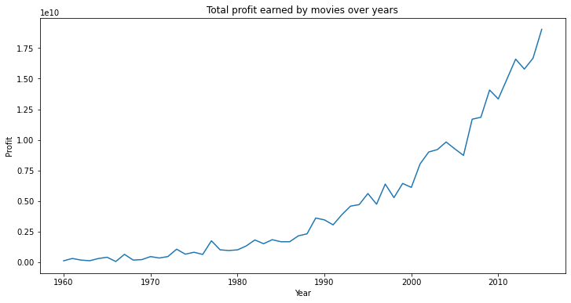

```python
profit_year = df_tmdb.groupby('release_year')['profit'].sum()
plt.figure(figsize = (12,6))

plt.xlabel('Year')
plt.ylabel('Profit')
plt.title('Total profit earned by movies over years')
plt.plot(profit_year)
plt.show()
```

Now from above graph we can conclude that the 2015 year was the year when movies made the highest profit after releasing in the theatre.

**Research Question 4) What is the average run time of all movies from dataset?**

```python
def avg_fun(column):
    return df_tmdb[column].mean()
```

```python
avg_fun('runtime')
```

```
102.3638545320288
```

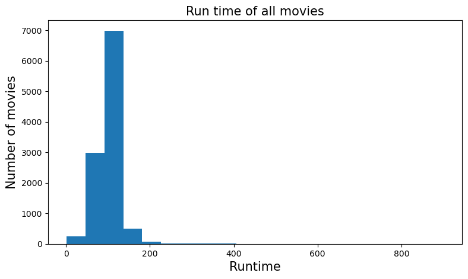

```python
plt.figure(figsize = (9,5), dpi= 100)

plt.xlabel('Runtime', fontsize = 15)
plt.ylabel('Number of movies', fontsize = 15)
plt.title('Run time of all movies', fontsize = 15)
plt.hist(df_tmdb['runtime'], bins = 20);
```

From above graph and analysis we can conclude that the average run time all the movies from the dataset is in between 80 to 150 minutes.

**Research Question 5) What are the movies genres present in the dataset? and which are the most popular genre year to year to make movies?**

```python
genres = df_tmdb['genres'].unique()
print(genres)
```

```
['Action|Adventure|Science Fiction|Thriller'
 'Adventure|Science Fiction|Thriller'
 'Action|Adventure|Science Fiction|Fantasy' ...
 'Adventure|Drama|Action|Family|Foreign' 'Comedy|Family|Mystery|Romance'
 'Mystery|Science Fiction|Thriller|Drama']
```

```python
def separate_count(column):
    split_data_tmdb = pd.Series(df_tmdb[column].str.cat(sep = '|').split('|'))

    count_data_tmdb = split_data_tmdb.value_counts(ascending=False)
    return count_data_tmdb
```

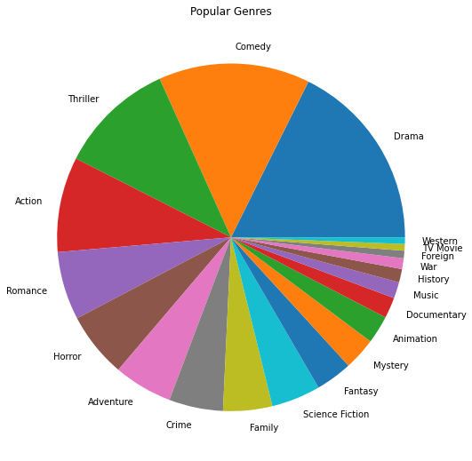

```python
separate_count("genres").plot(kind="pie",figsize=(9,9))
plt.title('Popular Genres')
plt.ylabel('');
```

**Research Question 6) Which movie has minimum profit?**

```python
df_tmdb[df_tmdb['profit'] == df_tmdb['profit'].min()]
```

|  | popularity | budget | revenue | profit | original_title | cast | director | runtime | genres | release_date | release_year |
| --- | --- | --- | --- | --- | --- | --- | --- | --- | --- | --- | --- |
| 2244 | 0.25054 | 425000000.0 | 11087569.0 | -413912431.0 | The Warrior's Way | Kate Bosworth\|Jang Dong-gun\|Geoffrey Rush\|Dann... | Sngmoo Lee | 100.0 | Adventure\|Fantasy\|Action\|Western\|Thriller | 2010-12-02 | 2010 |

**Research question 7)Which movie has maximum profit?**

```python
df_tmdb[df_tmdb['profit'] == df_tmdb['profit'].max()]
```

|  | popularity | budget | revenue | profit | original_title | cast | director | runtime | genres | release_date | release_year |
| --- | --- | --- | --- | --- | --- | --- | --- | --- | --- | --- | --- |
| 1386 | 9.432768 | 237000000.0 | 2.781506e+09 | 2.544506e+09 | Avatar | Sam Worthington\|Zoe Saldana\|Sigourney Weaver\|S... | James Cameron | 162.0 | Action\|Adventure\|Fantasy\|Science Fiction | 2009-12-10 | 2009 |

**Research Question 8) What us relaton between budget and revenue?**

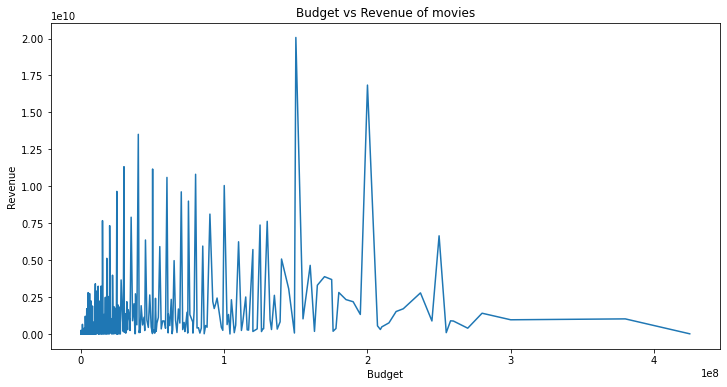

```python
budget_revenue = df_tmdb.groupby('budget')['revenue'].sum()
plt.figure(figsize = (12,6))

plt.xlabel('Budget')
plt.ylabel('Revenue')
plt.title('Budget vs Revenue of movies')
plt.plot(budget_revenue)
plt.show()
```

**Research Question 9) What is relation between popularity and runtime?**

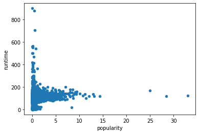

```python
df_tmdb.plot(x='popularity', y='runtime', kind='scatter');
```

**Key points to make a successful movie:**

**1)Average runtime of movie must be around 102 minutes.**

**2)Genres for popular movies are mainly : drama,comedy,thriller,action.**

**3)The film industry is profit industry over time.**

**Limitations: This dataset contains data of movies till year of 2015.The data was not completely clean or error free, some of the changes needed to be done to make proper analysis of the data.As mentioned in the data set budget and revenue columns contains zero values, because of which during analysis some error might occur.Datrtime format was incorrect so had to change it.**

**Communication: First we find the profit of all the movies by adding new column in the dataset by subtracting the budget from the revenue column so we can get the budget of all the movies over the years.Then as we can see that the datetime column from dataset is not in the proper format so, the datetime format is changed.Then we find the relation between profit and release year to get how the movies profit increases or decreases over the years.Then we find the average runtime and relation between runtime and popularity so we can get the result about how much runtime is needed to get movie be a successful in theatre.Which genre is famous or popular for a movie to be a successful.And at last we found the relation between the budget and revenue so wo get by how much budget we have to make to make more profit.**